# Analysis of CD8+ T cells profiled by scRNAseq

Veronika Niederlova

1.7.2022

# Initial processing

We start with datasets of sorted CD8+ T cells from blood of young or aged C57BL/6 mice that were profiled using the 10x Genomics Feature Barcode technology for Cell Surface Protein protocol (#CG000186 Rev D) with the Chromium Single Cell 5’ Library & Gel Bead and Chromium Single Cell 5’ Feature Barcode Library kits (10x Genomics, #PN-1000014, #PN-1000020, #PN-1000080, #PN-1000009, #PN-1000084). Demultiplexing and initial quality control is described in [Part 1].

In this document, we describe:

- Additional quality control of the data
- Integration of samples from young and aged mice
- Normalization, scaling, variable feature selection, dimensional reduction
- Differential expression testing
- Generation of figures for the manuscript

# Young mice

## Loading and cleaning data from young mice

```r
# Set path to dataset E02_BYB6_data_init.rds and load the data

path <- "datav02/init/E02_BYB6_data_init.rds"
seu <- readRDS(path)
```

We will filter out mitochondrial genes, genes encoding for ribosomal proteins, and genes encoding for TCR alpha and beta chains.

```r
# Remove mitochondrial, ribosomal, TRAV, TRBV and unannotated genes: blood young B6

seu_counts <- seu[["RNA"]]@counts
seu_counts_old <- seu[["RNA"]]@counts
seu_annots <- seu@meta.data
print(paste("Nrows before filtering genes:    ",nrow(seu)))
```

```
## [1] "Nrows before filtering genes:     12982"
```

```r
seu_counts <- seu[!(grepl('Trav', rownames(seu)) |
          grepl('Trbv', rownames(seu)) |
          grepl('mt-', rownames(seu)) |
            grepl('Rpl', rownames(seu)) |
          grepl('Rps', rownames(seu)) |
          grepl('MGP-', rownames(seu))),]

print(paste("Nrows after filtering genes:    ",nrow(seu_counts)))
```

```
## [1] "Nrows after filtering genes:     12870"
```

```r
# Create Seurat object with filtered genes

seu <- CreateSeuratObject(counts = seu_counts[["RNA"]]@counts, project = "seu", min.cells = 3, min.features = 200, meta.data = seu_annots)

# Process the blood young B6 dataset

seu <- NormalizeData(object = seu)
seu <- ScaleData(seu, verbose = FALSE)
seu <- FindVariableFeatures(seu, selection.method = "vst", nfeatures = 1000)
seu <- RunPCA(seu, npcs = 20, verbose = FALSE)
seu <- RunUMAP(seu, reduction = "pca", dims = 1:20)
seu <- FindNeighbors(seu, dims = 1:20)
seu <- FindClusters(seu, resolution = 0.6)
```

```
## Modularity Optimizer version 1.3.0 by Ludo Waltman and Nees Jan van Eck
##
## Number of nodes: 3492
## Number of edges: 120145
##
## Running Louvain algorithm...
## Maximum modularity in 10 random starts: 0.7473
## Number of communities: 9
## Elapsed time: 0 seconds
```

### Predicting cell types using SingleR

```r
# Annotate cell types using SingleR, version ‘1.0.1’
# For installation of the SingleR package, use:
# remotes::install_github("dviraran/SingleR", upgrade = "never")

counts <- GetAssayData(seu[["RNA"]])
seu_singler <- CreateSinglerObject(counts=counts,
  project.name= "B6", # choose
  min.genes = 200, # ignore cells with fewer than 200 transcripts
  technology = "10x", # choose
  species = "Mouse",
  citation = "Paprckova et al. 2022", # choose
  normalize.gene.length = FALSE,        # needed for full-length platforms (e.g. smartseq)
  variable.genes = "de",  # see vignette
  fine.tune = FALSE, # TRUE would take very long
  reduce.file.size = TRUE, # leave out less-often used fields
  do.signatures = FALSE,
  do.main.types = TRUE,
  numCores = 4)
```

```
## [1] "Dimensions of counts data: 11950x3492"
## [1] "Annotating data with Immgen..."
## [1] "Variable genes method: de"
## [1] "Number of DE genes:2024"
## [1] "Number of cells: 3492"
## [1] "Number of DE genes:2024"
## [1] "Number of clusters: 10"
## [1] "Annotating data with Immgen (Main types)..."
## [1] "Number of DE genes:1325"
## [1] "Number of cells: 3492"
## [1] "Number of DE genes:1325"
## [1] "Number of clusters: 10"
## [1] "Annotating data with Mouse-RNAseq..."
## [1] "Variable genes method: de"
## [1] "Number of DE genes:2113"
## [1] "Number of cells: 3492"
## [1] "Number of DE genes:2113"
## [1] "Number of clusters: 10"
## [1] "Annotating data with Mouse-RNAseq (Main types)..."
## [1] "Number of DE genes:1575"
## [1] "Number of cells: 3492"
## [1] "Number of DE genes:1575"
## [1] "Number of clusters: 10"
```

```r
## Summary of main cell types

seu <- AddMetaData(seu,
seu_singler$singler[[1]]$SingleR.single$labels,
                                 col.name = "Immgen_annot_single")

seu <- AddMetaData(seu,
seu_singler$singler[[1]]$SingleR.single.main$labels,
                                 col.name = "Immgen_annot_single_main")

seu <- AddMetaData(seu,
seu_singler$singler[[2]]$SingleR.single.main$labels,
                                 col.name = "MouseRNAseq_single_main")

seu <- AddMetaData(seu,
seu_singler$singler[[2]]$SingleR.single$labels,
                                 col.name = "MouseRNAseq_single")
```

We can see that according to SingleR annotations, some cells are probably contaminating B cells or monocytes. These cells will be removed in the next step.

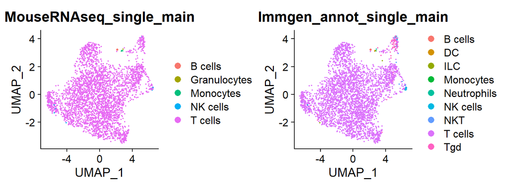

```r
DimPlot(seu, group.by = "MouseRNAseq_single_main") +
DimPlot(seu, group.by = "Immgen_annot_single_main")
```

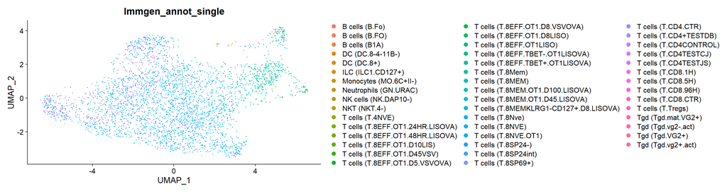

```r
DimPlot(seu, group.by = "Immgen_annot_single")
```

We can see that cluster 5 has low nCount_RNA, nFeature_RNA, high mt %, low ribo %, suggesting that these are dead or dying (low quality) cells.

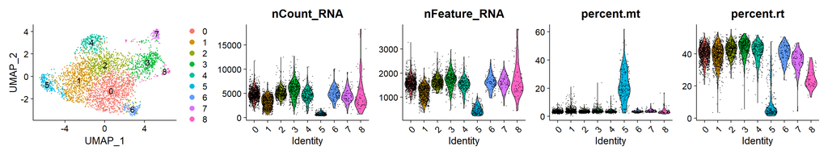

```r
DimPlot(seu, label = T) +
VlnPlot(seu, features = c("nCount_RNA","nFeature_RNA","percent.mt","percent.rt"), ncol = 4) +
  plot_layout(widths = c(1, 4))
```

### Remove contaminating and low quality cells

Removing clusters:

- Cluster 5 = low nCount_RNA, nFeature_RNA, high mt %, low ribo %

Removing cells:

- Mt percentage, filtration of cells with more than 10 %
- Mouse RNAseq annotation other than T cells, NK cells

```r
seu_filt <- subset(seu, percent.mt < 10 & seurat_clusters !=5 & MouseRNAseq_single %in% c("T cells", "NK cells"))
  seu_filt <- ScaleData(seu_filt, verbose = FALSE)
  seu_filt <- FindVariableFeatures(seu_filt, nfeatures = 1000, verbose = FALSE)
  seu_filt <- RunPCA(seu_filt, npcs = 12, verbose = FALSE)
  seu_filt <- RunUMAP(seu_filt, reduction = "pca", dims = 1:12)
  seu_filt <- FindNeighbors(seu_filt, dims = 1:12)
  seu_filt <- FindClusters(seu_filt, resolution = 0.3)
```

```
## Modularity Optimizer version 1.3.0 by Ludo Waltman and Nees Jan van Eck
##
## Number of nodes: 3236
## Number of edges: 106062
##
## Running Louvain algorithm...
## Maximum modularity in 10 random starts: 0.8084
## Number of communities: 6
## Elapsed time: 0 seconds
```

After filtering and re-clustering, we keep only high quality cells.

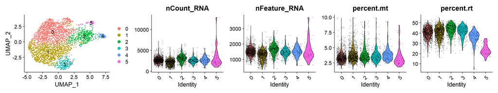

```r
DimPlot(seu_filt, label = T) +
VlnPlot(seu_filt, features = c("nCount_RNA","nFeature_RNA", "percent.mt","percent.rt"), ncol = 4) +
  plot_layout(widths = c(1, 4))
```

# Old mice

## Loading and cleaning data from old mice

```r
# Set path to dataset E02_BOB6_data_init.rds and load the data

path_old <- "datav02/init/E02_BOB6_data_init.rds"
seu_old <- readRDS(path_old)
```

We will filter out mitochondrial genes, genes encoding for ribosomal proteins, and genes encoding for TCR alpha and beta chains.

```r
# Remove mitochondrial, ribosomal, TRAV, TRBV and unannotated genes: blood young B6

seu_old_counts <- seu_old[["RNA"]]@counts
seu_old_counts_old <- seu_old[["RNA"]]@counts
seu_old_annots <- seu_old@meta.data
print(paste("Nrows before filtering genes:    ",nrow(seu_old)))
```

```
## [1] "Nrows before filtering genes:     13313"
```

```r
seu_old_counts <- seu_old[!(grepl('Trav', rownames(seu_old)) |
          grepl('Trbv', rownames(seu_old)) |
          grepl('mt-', rownames(seu_old)) |
            grepl('Rpl', rownames(seu_old)) |
          grepl('Rps', rownames(seu_old)) |
          grepl('MGP-', rownames(seu_old))),]

print(paste("Nrows after filtering genes:    ",nrow(seu_old_counts)))
```

```
## [1] "Nrows after filtering genes:     13201"
```

```r
# Create seu_oldrat object with filtered genes

seu_old <- CreateSeuratObject(counts = seu_old_counts[["RNA"]]@counts, project = "seu_old", min.cells = 3, min.features = 200, meta.data = seu_old_annots)

# Process the blood young B6 dataset

seu_old <- NormalizeData(object = seu_old)
seu_old <- ScaleData(seu_old, verbose = FALSE)
seu_old <- FindVariableFeatures(seu_old, selection.method = "vst", nfeatures = 1000)
seu_old <- RunPCA(seu_old, npcs = 20, verbose = FALSE)
seu_old <- RunUMAP(seu_old, reduction = "pca", dims = 1:20)
seu_old <- FindNeighbors(seu_old, dims = 1:20)
seu_old <- FindClusters(seu_old, resolution = 0.6)
```

```
## Modularity Optimizer version 1.3.0 by Ludo Waltman and Nees Jan van Eck
##
## Number of nodes: 3336
## Number of edges: 148153
##
## Running Louvain algorithm...
## Maximum modularity in 10 random starts: 0.8412
## Number of communities: 7
## Elapsed time: 0 seconds
```

```r
# Annotate cell types using SingleR, version ‘1.0.1’

counts_old <- GetAssayData(seu_old[["RNA"]])
seu_old_singler <- CreateSinglerObject(counts=counts_old,
  project.name= "B6", # choose
  min.genes = 200, # ignore cells with fewer than 200 transcripts
  technology = "10x", # choose
  species = "Mouse",
  citation = "Paprckova et al. 2022", # choose
  normalize.gene.length = FALSE,        # needed for full-length platforms (e.g. smartseq)
  variable.genes = "de",  # see vignette
  fine.tune = FALSE, # TRUE would take very long
  reduce.file.size = TRUE, # leave out less-often used fields
  do.signatures = FALSE,
  do.main.types = TRUE,
  numCores = 4)
```

```
## [1] "Dimensions of counts data: 12010x3336"
## [1] "Annotating data with Immgen..."
## [1] "Variable genes method: de"
## [1] "Number of DE genes:2029"
## [1] "Number of cells: 3336"
## [1] "Number of DE genes:2029"
## [1] "Number of clusters: 10"
## [1] "Annotating data with Immgen (Main types)..."
## [1] "Number of DE genes:1332"
## [1] "Number of cells: 3336"
## [1] "Number of DE genes:1332"
## [1] "Number of clusters: 10"
## [1] "Annotating data with Mouse-RNAseq..."
## [1] "Variable genes method: de"
## [1] "Number of DE genes:2134"
## [1] "Number of cells: 3336"
## [1] "Number of DE genes:2134"
## [1] "Number of clusters: 10"
## [1] "Annotating data with Mouse-RNAseq (Main types)..."
## [1] "Number of DE genes:1597"
## [1] "Number of cells: 3336"
## [1] "Number of DE genes:1597"
## [1] "Number of clusters: 10"
```

```r
## Summary of main cell types

seu_old <- AddMetaData(seu_old,
seu_old_singler$singler[[1]]$SingleR.single$labels,
                                 col.name = "Immgen_annot_single")

seu_old <- AddMetaData(seu_old,
seu_old_singler$singler[[1]]$SingleR.single.main$labels,
                                 col.name = "Immgen_annot_single_main")

seu_old <- AddMetaData(seu_old,
seu_old_singler$singler[[2]]$SingleR.single.main$labels,
                                 col.name = "MouseRNAseq_single_main")

seu_old <- AddMetaData(seu_old,
seu_old_singler$singler[[2]]$SingleR.single$labels,
                                 col.name = "MouseRNAseq_single")
```

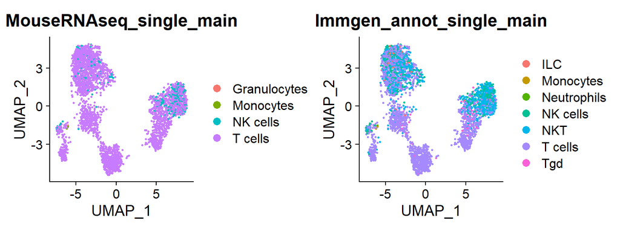

```r
DimPlot(seu_old, group.by = "MouseRNAseq_single_main") +
DimPlot(seu_old, group.by = "Immgen_annot_single_main")
```

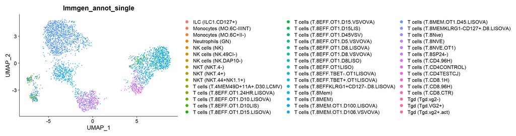

```r
DimPlot(seu_old, group.by = "Immgen_annot_single")
```

We can see that clusters 1 and 3 have low nCount_RNA, nFeature_RNA, high mt %, low ribo %, suggesting that these are dead or dying (low quality) cells.

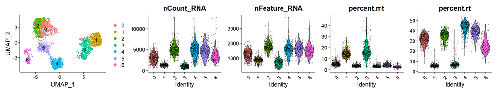

```r
DimPlot(seu_old, label = T) +
VlnPlot(seu_old, features = c("nCount_RNA","nFeature_RNA","percent.mt","percent.rt"), ncol = 4) +
  plot_layout(widths = c(1, 4))
```

## Remove contaminating and low quality cells

Removing clusters:

- Clusters 1 and 3 = low nCount_RNA, nFeature_RNA, high mt %, low ribo %, no expression of CD3 or Trac

Removing cells:

- Mt filtration 10 %
- Mouse RNAseq annotation other than T cells, NK cells

```r
seu_old_filt <- subset(seu_old, percent.mt < 10 & seurat_clusters %in% c(0,2,4:6) & MouseRNAseq_single %in% c("T cells", "NK cells"))


seu_old_filt <- ScaleData(seu_old_filt, verbose = FALSE)
seu_old_filt <- FindVariableFeatures(seu_old_filt, nfeatures = 1000, verbose = FALSE)
seu_old_filt <- RunPCA(seu_old_filt, npcs = 12, verbose = FALSE)
seu_old_filt <- RunUMAP(seu_old_filt, reduction = "pca", dims = 1:12)
seu_old_filt <- FindNeighbors(seu_old_filt, dims = 1:12)
seu_old_filt <- FindClusters(seu_old_filt, resolution = 0.3)
```

```
## Modularity Optimizer version 1.3.0 by Ludo Waltman and Nees Jan van Eck
##
## Number of nodes: 2225
## Number of edges: 85382
##
## Running Louvain algorithm...
## Maximum modularity in 10 random starts: 0.8722
## Number of communities: 4
## Elapsed time: 0 seconds
```

After filtering and re-clustering, we keep only high quality cells.

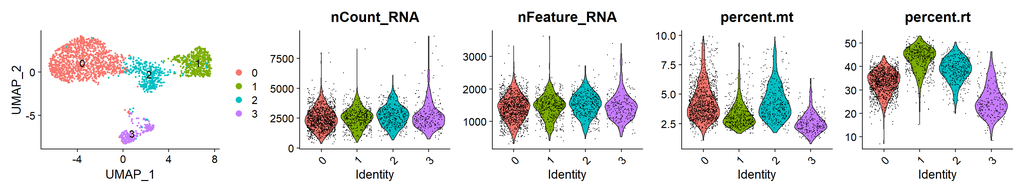

```r
DimPlot(seu_old_filt, label = T) +
VlnPlot(seu_old_filt, features = c("nCount_RNA","nFeature_RNA", "percent.mt","percent.rt"), ncol = 4) +
  plot_layout(widths = c(1, 4))
```

# Integration of young and old

The next step is to integrate the two samples from young and aged mice together. We will use the filtered datasets that were produced in the previous section as input.

```r
seu_filt <- readRDS("data/filt/E02_BYB6_data_filt.rds")
seu_old_filt <-  readRDS("data/filt/E02_BOB6_data_filt.rds")

b6_blood <- merge(seu_old_filt, seu_filt)

# split the dataset into a list of two seurat objects (stim and CTRL)
b6_blood.list <- SplitObject(b6_blood, split.by = "orig.ident")


# normalize and identify variable features for each dataset independently
b6_blood.list <- lapply(X = b6_blood.list, FUN = function(x) {
    x <- NormalizeData(x)
    x <- FindVariableFeatures(x, selection.method = "vst", nfeatures = 500)
})

# select features that are repeatedly variable across datasets for integration
features <- SelectIntegrationFeatures(object.list = b6_blood.list)
b6_blood.anchors <- FindIntegrationAnchors(b6_blood.list, dims = 1:10)
b6_blood.integrated <- IntegrateData(anchorset = b6_blood.anchors, dims = 1:10)
DefaultAssay(b6_blood.integrated) <- "integrated"
b6_blood.integrated <- ScaleData(b6_blood.integrated, verbose = FALSE)
b6_blood.integrated <- FindVariableFeatures(b6_blood.integrated, selection.method = "vst", nfeatures = 500,
        verbose = FALSE)
b6_blood.integrated <- RunPCA(b6_blood.integrated, npcs = 24, verbose = FALSE)
b6_blood.integrated <- RunUMAP(b6_blood.integrated, reduction = "pca", dims = 1:24)
b6_blood.integrated <- FindNeighbors(b6_blood.integrated, dims = 1:24)
b6_blood.integrated <- FindClusters(b6_blood.integrated, resolution = 0.5)
```

```
## Modularity Optimizer version 1.3.0 by Ludo Waltman and Nees Jan van Eck
##
## Number of nodes: 5461
## Number of edges: 193124
##
## Running Louvain algorithm...
## Maximum modularity in 10 random starts: 0.7828
## Number of communities: 6
## Elapsed time: 0 seconds
```

```r
print(DimPlot(b6_blood.integrated, reduction = "umap", group.by = "seurat_clusters", label = TRUE) + ggtitle(i))
```

[output not shown]

```r
#DimPlot(b6_blood.integrated, reduction = "umap", group.by = "orig.ident", label = TRUE)

b6_blood.integrated$annot <- recode(b6_blood.integrated$seurat_clusters,
                                    `0` = "Naive",
                                    `1` = "AIMT",
                                    `2` = "AIMT",
                                    `3` = "Naive",
                                    `4` = "AE",
                                    `5` = "IRENA")
```

After integration, we obtained six clusters. All clusters are present in young and aged animals.

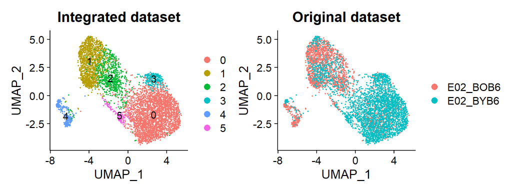

```r
DimPlot(b6_blood.integrated, reduction = "umap", group.by = "seurat_clusters", label = TRUE) + ggtitle("Integrated dataset") + (DimPlot(b6_blood.integrated, group.by = "orig.ident") + ggtitle("Original dataset"))
```

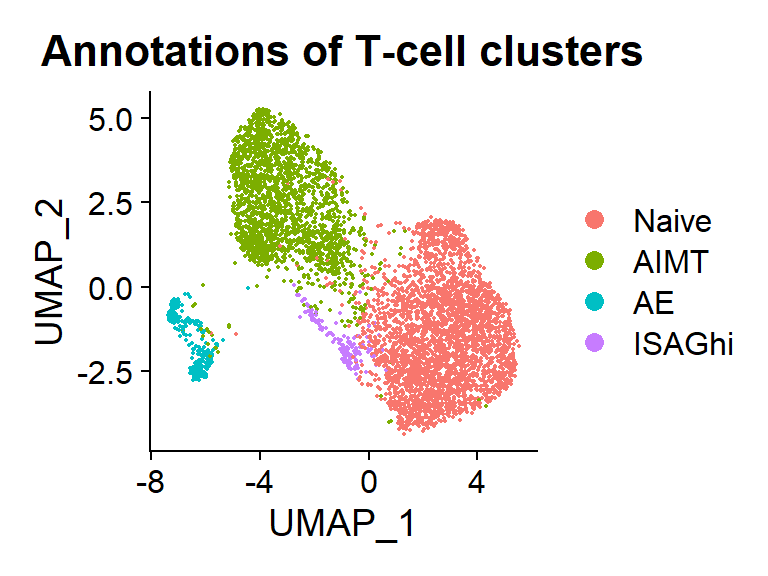

```r
b6_blood.integrated$annot <- recode(b6_blood.integrated$seurat_clusters,
                                    `0` = "Naive",
                                    `1` = "AIMT",
                                    `2` = "AIMT",
                                    `3` = "Naive",
                                    `4` = "AE",
                                    `5` = "ISAGhi")
DimPlot(b6_blood.integrated, group.by = "annot") + ggtitle("Annotations of T-cell clusters")
```

# Differentially expressed genes

Markers are saved in a csv table markers.csv. Top 5 positive markers for each cluster are listed in a table below:

```r
markers_filt <- FindAllMarkers(b6_blood.integrated, assay = "RNA", logfc.threshold = log(1.5), slot = "counts", min.diff.pct = 0.05)

df <- markers_filt %>% filter(avg_log2FC > 0) %>% group_by(cluster) %>%  slice_head(n = 5)

kable(df, format = "html") %>%
  kable_styling(full_width = F, font_size = 12,bootstrap_options = c("striped", "hover", "condensed", "responsive"))
```

| p_val | avg_log2FC | pct.1 | pct.2 | p_val_adj | cluster | gene |
| --- | --- | --- | --- | --- | --- | --- |
| 0 | 1.0099970 | 0.915 | 0.496 | 0 | 0 | Ccr7 |
| 0 | 1.1826462 | 0.543 | 0.105 | 0 | 0 | Igfbp4 |
| 0 | 0.7958230 | 0.918 | 0.630 | 0 | 0 | Lef1 |
| 0 | 0.7104409 | 0.933 | 0.740 | 0 | 0 | Npc2 |
| 0 | 0.7625458 | 0.718 | 0.345 | 0 | 0 | Rflnb |
| 0 | 1.9830477 | 0.986 | 0.354 | 0 | 1 | Ccl5 |
| 0 | 1.7810327 | 0.794 | 0.120 | 0 | 1 | Klrk1 |
| 0 | 1.7277997 | 0.777 | 0.094 | 0 | 1 | Gzmm |
| 0 | 1.6521329 | 0.988 | 0.463 | 0 | 1 | Ly6c2 |
| 0 | 1.4129748 | 0.837 | 0.195 | 0 | 1 | S100a6 |
| 0 | 0.8176514 | 0.955 | 0.525 | 0 | 2 | Ly6c2 |
| 0 | 0.7590350 | 0.877 | 0.439 | 0 | 2 | Ccl5 |
| 0 | 0.5047058 | 0.835 | 0.534 | 0 | 2 | Il2rb |
| 0 | 0.5032091 | 0.629 | 0.298 | 0 | 2 | S100a6 |
| 0 | 0.8551345 | 0.571 | 0.055 | 0 | 3 | Bcl3 |
| 0 | 2.1498669 | 0.970 | 0.512 | 0 | 3 | Nfkbia |
| 0 | 0.7456107 | 0.578 | 0.104 | 0 | 3 | Relb |
| 0 | 1.0944716 | 0.675 | 0.194 | 0 | 3 | Icam1 |
| 0 | 0.4989786 | 0.433 | 0.095 | 0 | 3 | Nfkb2 |
| 0 | 2.1292420 | 0.751 | 0.032 | 0 | 4 | Gzmk |
| 0 | 1.6284758 | 0.458 | 0.007 | 0 | 4 | Lgals3 |
| 0 | 0.7699561 | 0.344 | 0.001 | 0 | 4 | Klrg1 |
| 0 | 0.7227044 | 0.352 | 0.001 | 0 | 4 | Cx3cr1 |
| 0 | 1.0019137 | 0.431 | 0.024 | 0 | 4 | Tigit |
| 0 | 1.2421496 | 0.628 | 0.038 | 0 | 5 | Ifit1 |
| 0 | 1.4887950 | 0.717 | 0.076 | 0 | 5 | Isg15 |
| 0 | 1.1548404 | 0.586 | 0.067 | 0 | 5 | Ifit3 |
| 0 | 1.0512011 | 0.745 | 0.145 | 0 | 5 | Rtp4 |
| 0 | 0.4237152 | 0.297 | 0.022 | 0 | 5 | Oasl2 |

```r
# write.csv(markers_filt, file = "markers.csv", row.names = F)
```

# Figure 1

## Fig 1A

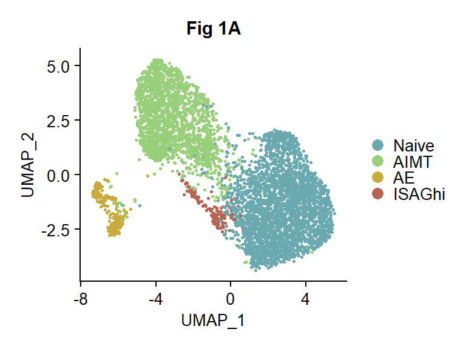

```r
## Main figure - reduced clusters
DimPlot(b6_blood.integrated, pt.size = 0.5, label = F, group.by = "annot", cols = c("#69a9af", "#99cf7bff", "#c8ab3a", "#b96355" )) + ggtheme() + ggtitle("Fig 1A")
```

## Fig 1B

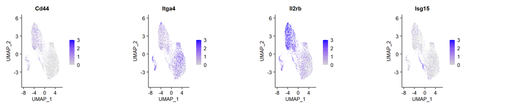

```r
p1 <- FeaturePlot(b6_blood.integrated, reduction = "umap", features = c("Cd44"), ncol = 2, min.cutoff = 0, raster = T, max.cutoff = 3) + ggtheme()

p2 <- FeaturePlot(b6_blood.integrated, reduction = "umap", features = c("Itga4"), ncol = 2, min.cutoff = 0, raster = T, max.cutoff = 3) + ggtheme()

p3 <- FeaturePlot(b6_blood.integrated, reduction = "umap", features = c("Il2rb"), ncol = 2, min.cutoff = 0, raster = T, max.cutoff = 3) + ggtheme()

p4 <- FeaturePlot(b6_blood.integrated, reduction = "umap", features = c("Isg15"), ncol = 2, min.cutoff = 0, raster = T, max.cutoff = 3) + ggtheme()

plot_grid(p1, p2, p3, p4, ncol = 4)
```

## Fig 1C

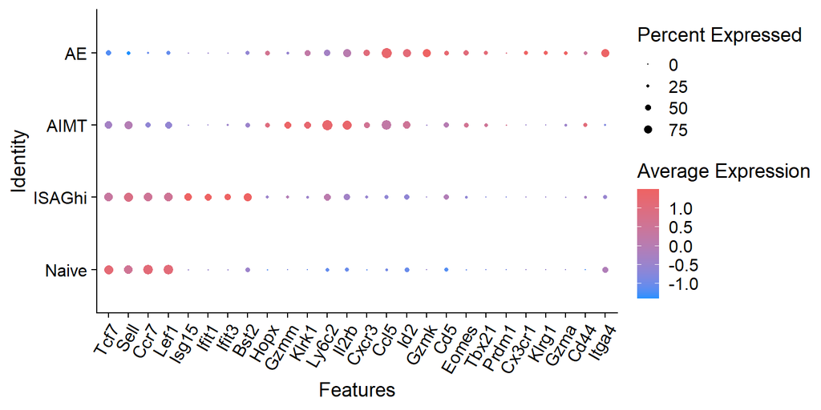

```r
Idents(b6_blood.integrated) <- b6_blood.integrated$annot
DotPlot(b6_blood.integrated, features = c("Tcf7", "Sell","Ccr7","Lef1",
                                          "Isg15", "Ifit1", "Ifit3", "Bst2",
                                         "Hopx", "Gzmm","Klrk1","Ly6c2","Il2rb",
                                          "Cxcr3","Ccl5","Id2","Gzmk","Cd5",
                                          "Eomes","Tbx21", "Prdm1","Cx3cr1","Klrg1",
                                          "Gzma","Cd44",
                                          "Itga4"), assay = "RNA",
        cluster.idents = TRUE,
        cols = c("dodgerblue","indianred2"),
        dot.scale = 3) +
  theme(axis.text.x = element_text(angle = 60, hjust = 1, vjust = 1))
```

## Fig 1D

```r
#GOLDRATH_NAIVE_VS_MEMORY_CD8_TCELL_DOWN
```

```
#> Genes down-regulated in comparison of naive CD8 T cells versus memory CD8 T cells.
```

```r
naive_memory_down <- c("ABCB1", "ABHD5", "ACOT7", "ACY1", "AHNAK", "AIF1", "CRYBG1", "ANKH", "ANTXR2", "ANXA1", "ANXA2", "AQP9", "ARL6", "ART3", "ASAH1", "ATF6", "BAG3", "BCL2A1", "BCL2L2", "BHLHE40", "CAPG", "CAPN2", "CASP1", "CASP4", "YJU2B", "CCL4", "CCL5", "CCND3", "CCR2", "CCR5", "CD160", "CD22", "CD44", "CHCHD7", "CHPT1", "CISH", "CLDND1", "CPNE3", "CRTAM", "CST7", "CTNNA1", "CTSW", "CXCR3", "CYB5R4", "CYBB", "CYFIP1", "CYP4V2", "DAPK2", "DBNDD2", "DENND4C", "DENND5A", "DNAJC5", "DOCK5", "DSTN", "ECI1", "EEA1", "EI24", "ELL2", "EMP1", "ENPP1", "EOMES", "ERRFI1", "EVI2A", "EYA4", "F2R", "FASLG", "FCGR2B", "FCGRT", "FGL2", "FHIT", "GABARAPL2", "GATA3", "GCAT", "GCLM", "GGH", "GK", "GLRX", "GOLIM4", "GOLM1", "GPC1", "GPHN", "GSTO1", "GZMA", "GZMB", "GZMK", "GZMM", "HCFC1R1", "HIP1R", "HSD17B11", "ID2", "IER3", "IFITM10", "IFNG", "IL10RB", "IL15", "IL15RA", "IL18R1", "IL18RAP", "IRF8", "ITGAX", "ITGB1", "ITM2C", "KCNJ8", "KCTD12", "PALD1", "CIPC", "KLHL7", "KLRC1", "KLRG1", "KLRK1", "KRTCAP2", "LGALS1", "LGALS3", "LIMD1", "LITAF", "LPGAT1", "LPIN1", "MAP3K8", "MAPK12", "MAPRE2", "SLC25A53", "MCOLN2", "MDFIC", "MED10", "MGST3", "MS4A1", "MYADM", "MYL1", "MYO1F", "N4BP1", "NBEAL2", "NCKAP1", "NOTCH4", "NRP1", "ODC1", "OSTF1", "PBX3", "PGAM1", "PGLYRP1", "PHF13", "PLAT", "PLBD1", "PLCD1", "PLEKHA5", "PLEKHB2", "PLP2", "PLSCR1", "POLR1B", "POU6F1", "PPP3CC", "SLC66A3", "PRDM1", "PRF1", "PRKCA", "PRSS12", "PTPN13", "PTPN22", "RAB3D", "RASA4", "RECK", "RNASE4", "RNF138", "RPGR", "S100A10", "S100A13", "S100A4", "S100A6", "SAMHD1", "SEMA4A", "SEMA4F", "SERPINB6", "SERPINB9", "SKAP2", "SLC35E4", "SMYD1", "SNX10", "SOAT2", "SOCS2", "SOS2", "SSX2IP", "ST3GAL4", "ST3GAL6", "STARD10", "STX7", "TK1", "TKTL1", "TMEM141", "LDAF1", "TMEM37", "PIP4P2", "TNFRSF1B", "TRAF1", "TRAF3IP2", "TSPAN4", "TUSC2", "TXNDC5", "UNC119B", "VKORC1", "VMP1", "XIST")


naive_memory_down2 <- convertHumanGeneList2(naive_memory_down)
```

```
## [1] "Mapre2"  "Rnf138"  "Lpin1"   "Gm6169"  "Ctsw"    "Gm21970"
```

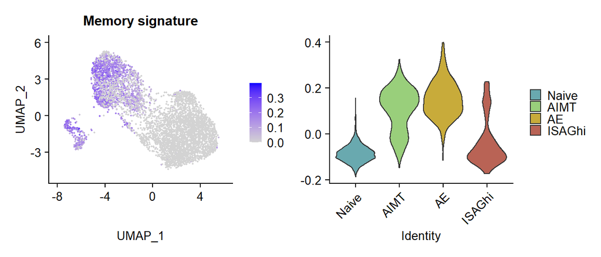

```r
naive_memory_down_filt <- naive_memory_down2[which(naive_memory_down2 %in% rownames(b6_blood.integrated[["RNA"]]))]

b6_blood.integrated <- AddModuleScore(
  object = b6_blood.integrated,
  features = list(c(naive_memory_down_filt)),
  assay = "RNA",
  name = 'Naive_memory_down_signature_'
)


(FeaturePlot(b6_blood.integrated, features = "Naive_memory_down_signature_1", min.cutoff = 0) + ggtheme() + ggtitle("Memory signature")) +
(VlnPlot(b6_blood.integrated, features = "Naive_memory_down_signature_1", group.by = "annot", pt.size = 0, cols = c("#69a9af","#99cf7bff","#c8ab3a","#b96355" )) + ggtitle("") + ggtheme()) + plot_layout(ncol = 2)
```

## Fig 1E

```r
# STANDARD_NAME GOLDRATH_NAIVE_VS_EFF_CD8_TCELL_DN
# SYSTEMATIC_NAME   M3036
# DESCRIPTION_BRIEF Genes down-regulated in comparison of naïve CD8 T cells versus effector CD8 T cells.


naive_eff_down <- c("ACOT7", "ADAM8", "ANLN", "ANXA1", "ANXA2", "ANXA4", "ARHGAP21", "ASF1B", "ASPM", "ATP5IF1", "AURKA", "AURKB", "BATF3", "BCL2A1", "BHLHE40", "BIRC5", "BMP2K", "BRCA1", "BUB1", "VPS51", "CMC2", "C3", "HPF1", "C6orf89", "CA1", "CA2", "CAPG", "CAPN2", "CARHSP1", "CASP3", "CCL4", "CCNA2", "CCNB2", "CCNF", "CCR2", "CCR5", "CD244", "CD48", "CD99", "CDC25C", "CDC45", "CDC6", "CDCA3", "CDCA5", "CDCA8", "CDK1", "CDK2AP1", "CDKN2C", "CDKN3", "CENPA", "CHAF1A", "CHEK1", "CISD1", "CISH", "CKS1B", "CKS2", "CRMP1", "CYFIP1", "DHFR", "DLGAP5", "DOCK5", "DSTN", "DTL", "E2F8", "ECT2", "EEA1", "EFHD2", "ELL2", "EMP1", "EMP3", "ERRFI1", "EZH2", "F2RL3", "FASLG", "FCER1G", "FGL2", "FHL2", "GALNT3", "GCAT", "GEM", "GLRX", "GMNN", "GNG10", "GNPDA1", "GZMA", "GZMB", "GZMK", "GZMM", "H1-0", "H2AX", "H2AZ1", "H1-2", "HOPX", "IFI30", "IFITM3", "IFNG", "JCHAIN", "IGKC", "IGLC7", "INCENP", "IRF4", "IRF8", "ITGAX", "ITGB1", "PCLAF", "KIF11", "KIF20A", "KIF22", "KIF2C", "KIF4A", "KIFC1", "KLRG1", "KLRK1", "KRTCAP2", "LAG3", "LGALS1", "LGALS3", "LIG1", "LITAF", "LPIN1", "LYN", "MAD2L1", "MAPK6", "MAPRE2", "MCM10", "MCM5", "MDFIC", "MIS18BP1", "MKI67", "MS4A1", "MT1E", "MT2A", "MTM1", "MTMR9", "MYADM", "MYO1F", "NAPSA", "NCAPH", "NEK2", "NPPA", "NRP1", "NUDT4", "NUSAP1", "ODC1", "PCNA", "PDCD1", "PERP", "PGAM1", "PLD4", "PLIN2", "PLK4", "PLP2", "PLSCR1", "POLA1", "PRC1", "PRDM1", "PRDX4", "PRF1", "PRIM1", "PRIM2", "RAB11A", "RAD51", "REEP5", "RFC5", "RHD", "RHOQ", "RNASEH2B", "ROM1", "RRM1", "S100A10", "S100A4", "S100A6", "SCPEP1", "SERINC3", "SERPINB6", "SERPINB9", "SH3BGRL", "SKAP2", "SNX10", "SOCS2", "STARD10", "STMN1", "SYPL1", "TACC3", "TBL2", "TCF19", "TK1", "TKTL1", "TMEM14C", "TMEM37", "TNFRSF9", "TOP2A", "TPI1", "TTK", "TXN", "TYMS", "UBE2T", "UBL3", "UNC119", "VCL")


naive_eff_down2 <- convertHumanGeneList2(naive_eff_down)
```

```
## [1] "Mapre2"   "Lpin1"    "Lgals3"   "Cdc25c"   "Kif20a"   "Rnaseh2b"
```

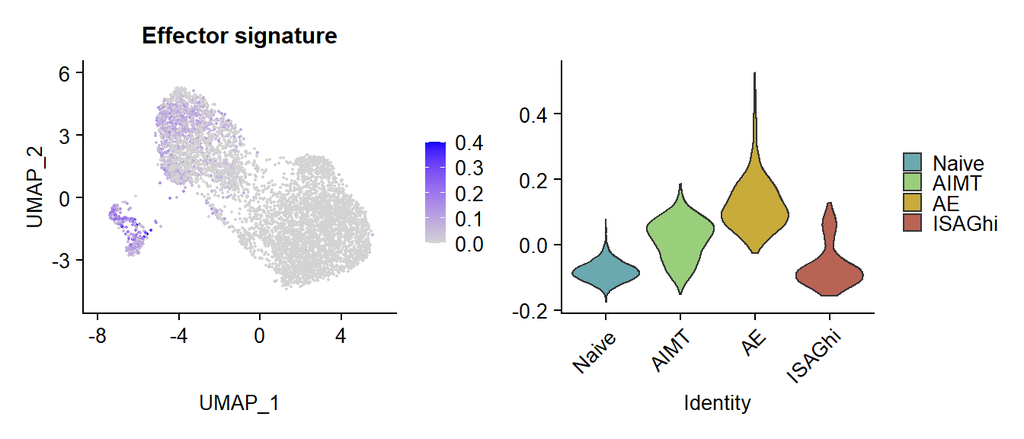

```r
naive_eff_down_filt <- naive_eff_down2[which(naive_eff_down2 %in% rownames(b6_blood.integrated[["RNA"]]))]



b6_blood.integrated <- AddModuleScore(
  object = b6_blood.integrated,
  features = list(c(naive_eff_down_filt)),
  assay = "RNA",
  name = 'Naive_eff_down_signature_'
)

(FeaturePlot(b6_blood.integrated, features = "Naive_eff_down_signature_1", min.cutoff = 0, max.cutoff = 0.4) + ggtheme() + ggtitle("Effector signature")) +
(VlnPlot(b6_blood.integrated, features = "Naive_eff_down_signature_1", group.by = "annot", pt.size = 0, cols = c("#69a9af","#99cf7bff","#c8ab3a","#b96355")) + ggtitle("") + ggtheme()) + plot_layout(ncol = 2)
```

## Fig 1F

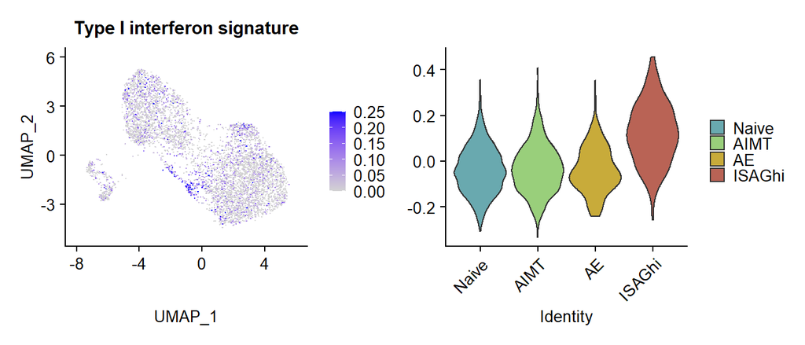

```r
# Interferon GO:0060338
# regulation of type I interferon-mediated signaling pathway

interferon <-  c("Oas1g", "Mmp12", "Ube2k", "Usp29", "Zbp1", "Dcst1", "Usp27x", "Irf7", "Ythdf3", "Irf3", "Trim56", "Mavs", "Trim6", "Trim41", "Oas1a", "Oas1f", "Oas1h", "Oas3", "Ptpn2", "Ttll12", "Oas1d", "Rnf185", "Mul1", "Trex1", "Sting1", "Ikbke", "Tbk1", "Stat2", "Isg15", "Fadd", "Mettl3", "Samhd1", "Cdc37", "Cactin", "Ythdf2", "Wnt5a", "Cnot7", "Oas1c", "Lsm14a", "Adar", "Nlrc5", "Oas1e")


interferon_filt <- interferon[which(interferon %in% rownames(b6_blood.integrated[["RNA"]]))]

b6_blood.integrated <- AddModuleScore(
  object = b6_blood.integrated,
  features = list(c(interferon_filt)),
  assay = "RNA",
  name = 'Interferon_signature_'
)

(FeaturePlot(b6_blood.integrated, features = "Interferon_signature_1", raster = T, ncol = 2, min.cutoff = 0, max.cutoff = 0.25) + ggtheme() + ggtitle("Type I interferon signature")) +
(VlnPlot(b6_blood.integrated, features = "Interferon_signature_1", group.by = "annot", pt.size = 0, cols = c("#69a9af","#99cf7bff","#c8ab3a","#b96355")) + ggtitle("") + ggtheme()) + plot_layout(ncol = 2)
```

## Fig 1G

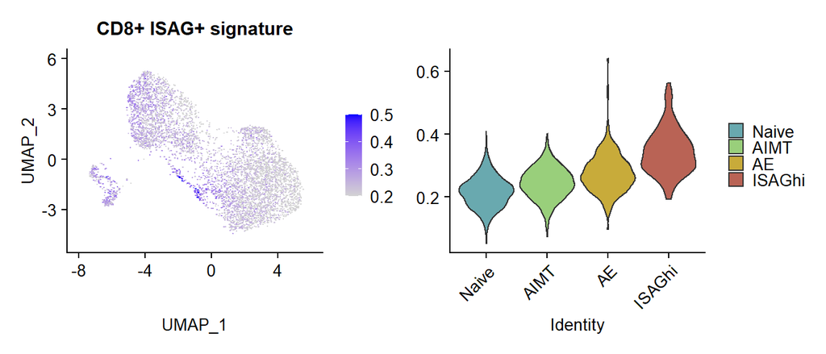

```r
sig_genes_cl15 <- c("IFIT1", "RSAD2", "IFIT3", "IFI44L", "MX1", "IFI6", "OAS1", "CMPK2", "ISG15", "OAS3", "IFIT2", "HERC5", "USP18", "MX2", "IFI44", "LAMP3", "XAF1", "EPSTI1", "EIF2AK2", "PLSCR1", "STAT1", "LY6E", "LGALS9", "SAMD9L", "IFI35", "IRF7", "ISG20", "OAS2", "PARP9", "GBP1", "IFITM1", "TRIM22", "OASL", "SAMD9", "BST2", "IFIH1", "UBE2L6", "DDX60", "LAP3", "DDX60L", "DDX58", "HELZ2", "CD38", "PARP14", "HERC6", "PNPT1", "STAT2", "HSH2D", "RTP4", "MT2A", "IFIT5", "NT5C3A", "RNF213", "ZBP1", "TNFSF10", "LAG3", "SP100", "TYMP", "IFI16", "C19orf66", "DRAP1", "SP110", "SPATS2L", "GBP4", "PPM1K", "IFI27", "ADAR", "DTX3L", "PARP12", "PARP10", "PHF11", "IFITM3", "PSMB9", "TAP1", "AKAP2", "SAT1", "B2M", "NMI", "CHMP5", "IFITM2", "PML", "GBP5", "ZNFX1", "ETV7", "APOL6", "CARD16", "NUB1", "HAPLN3", "TRANK1", "TRIM25", "CNP", "C5orf56", "RBCK1", "TMEM140", "FBXO6", "DHX58", "CHST12", "TRAFD1", "RARRES3", "XRN1", "PSME2", "CASP1", "PSMB8", "BCL2L14", "SHISA5", "ODF3B", "SLFN5", "SP140", "HLA-A", "TRIM21", "CCR1", "N4BP1", "HLA-C", "HLA-B", "SMCHD1", "NAPA", "HLA-E", "MOV10", "MYL12A", "NEXN", "GBP2", "ALOX5AP", "CD164", "TMEM123", "ENDOD1", "TMSB10", "WARS", "MYD88", "SLC38A5", "TRIM14", "HELB", "PRKD2", "PSME1", "RASGRP3", "TRIM38", "APOL1", "ODF2L", "DYNLT1", "TMSB4X", "TANK", "ECE1", "APOL2", "TDRD7", "PSMB10", "AZI2", "COX5A", "PI4K2B", "USP15", "IRF9", "PTMS", "CMTR1", "CD74", "GNG5", "ELF1", "PPP1CC", "RGS1", "EHD4", "LGALS3BP", "SAMHD1", "GSDMD", "LPIN2", "CD48", "SLFN12L", "GIMAP4", "IDH2", "GBP3", "TRIM5", "OGFR", "EVL", "PSMA5", "WIPF1", "C4orf3", "STOM", "HM13", "TBC1D1", "SLA2", "FCHSD2", "TAPBP", "SNX6", "ZCCHC2", "HLA-DPA1", "TNK2", "IRF2", "KPNB1", "TMX1", "COTL1", "CALCOCO2", "PRF1", "C1GALT1", "TNFSF13B", "SCLT1", "APOBEC3G", "CAPN2", "CD2", "TRIM69", "GPBP1", "MCOLN2", "GPR155", "UTRN", "CCDC85B", "CLEC2B", "ERAP2", "CTSS", "PCGF5", "MVP", "GZMB", "CD47", "TRIM56", "YEATS2", "BAK1", "GZMA", "DNAJA1", "IRF1", "PGAP1", "CASP7", "UBC", "VAMP5", "FANCA", "IL15RA", "PARP8", "KLHDC7B", "TRIM34", "AIM2", "DAPP1", "TAP2", "GIMAP7", "BRCA2", "L3HYPDH", "APOBEC3H", "LYSMD2", "CARD17", "GALM", "RAC2", "SUSD3", "SUB1", "MTHFD2", "IFI30", "MLKL", "BAG1", "S100A11", "GPR180", "SCARB2", "H3F3B", "CNDP2", "SCO2", "PARP11", "USP30-AS1", "HLA-DRA", "GSTK1", "ARHGEF3", "ANKFY1", "SOCS1", "SETX", "FASLG", "CXCL13", "NLRC5", "DEGS1", "CAPG", "PRR5", "TRIM26", "DOPEY1", "HLA-DRB1", "JAK2", "PSMA6", "CD68", "UBA7", "EXOC2", "GIMAP2", "CSF1", "ACP5", "MRPL17", "TDRD3", "TRADD", "L3MBTL3", "CFLAR", "PMAIP1", "HSPA1A", "HAVCR2", "CTSC", "CLDND1", "OPTN", "GPR171", "ZC3HAV1", "MICB", "CCL5", "TGM1", "PSMA3", "WDFY1", "CCR5", "TIMD4", "OTOF", "RNF149", "LNPEP", "CASP4", "STX17", "CLEC2D", "NDC80", "TMEM62", "SERPINB1", "PTK2B", "TMEM109", "MYL12B", "RBPJ", "SUPT3H", "PYURF", "PDCD1", "DNPEP", "CXCR6", "CD69", "TMEM50A", "DERL1", "UVRAG", "MZB1", "ME2", "TTC21A", "MCL1", "LMNB1", "GTPBP1", "AFF1", "ITGA1", "ARPC3", "LGALS8", "ANKIB1", "HLA-DPB1", "PSMA2", "RBX1", "CLIC3")

b6_blood.integrated <- AddModuleScore(
  object = b6_blood.integrated,
  features = list(c(sig_genes_cl15)),
  search = T,
  assay = "RNA",
  name = 'PanCancerCD8Tcell_Cluster15_signature_'

)

(FeaturePlot(b6_blood.integrated, features = "PanCancerCD8Tcell_Cluster15_signature_1", raster = T, ncol = 2, min.cutoff = 0.2, max.cutoff = 0.5) + ggtheme() + ggtitle("CD8+ ISAG+ signature")) +
(VlnPlot(b6_blood.integrated, features = "PanCancerCD8Tcell_Cluster15_signature_1", group.by = "annot", pt.size = 0, cols = c("#69a9af","#99cf7bff","#c8ab3a","#b96355")) + ggtitle("") + ggtheme()) + plot_layout(ncol = 2)
```

## Fig 1H

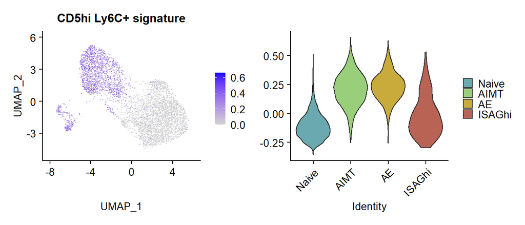

```r
CD5lo_CD5hiLy6Cpos_g <-c("Ly6c1", "Cxcr3", "A430093F15Rik", "LOC268288", "Plac8", "Ccl5", "A530021J07Rik",
"Pde2a", "Xcl1", "Pglyrp1", "Anxa2", "Reck", "Dapl1", "LOC675594",
 "Tbx21", "F2rl1", "LOC624610", "Eomes", "Endod1", "Zfp296", "Prss12",
 "3110013H01Rik", "Aim1", "Plekhg3", "C230043G09Rik", "A630064F15Rik", "2210411K11Rik", "Pdlim7",
 "Xdh", "Gsto1", "scl0004175.1_57", "D8Ertd82e", "Gsg2", "Acsbg1", "Serpina3g",
 "6330509M05Rik", "Slpi", "Car11", "Adamtsl4", "Hopx", "Chn2", "LOC630146",
 "X99384" )


b6_blood.integrated <- AddModuleScore(
  object = b6_blood.integrated,
  features = list(c(CD5lo_CD5hiLy6Cpos_g)),
  search = T,
  assay = "RNA",
  name = 'JunJu_CD5lo_CD5hiLy6Cpos_signature_'

)

(FeaturePlot(b6_blood.integrated, features = "JunJu_CD5lo_CD5hiLy6Cpos_signature_1", raster = T, ncol = 2, min.cutoff = 0) + ggtheme() + ggtitle("CD5hi Ly6C+ signature")) +
(VlnPlot(b6_blood.integrated, features = "JunJu_CD5lo_CD5hiLy6Cpos_signature_1", group.by = "annot", pt.size = 0, cols = c("#69a9af","#99cf7bff","#c8ab3a","#b96355")) + ggtitle("") + ggtheme()) + plot_layout(ncol = 2)
```

## Fig 1I

Plots show the percentage of cells in each cluster for young and old animals, respectively. The plots were combined manually.

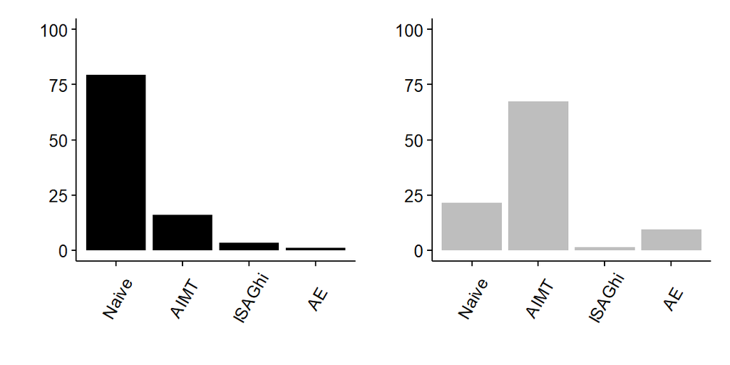

```r
df4 <- b6_blood.integrated@meta.data %>% group_by(orig.ident, annot) %>%
  summarise(n = n()) %>%
  mutate(freq = n / sum(n))


# Stacked barplot young
p11 <- df4 %>%
  filter(orig.ident == "E02_BYB6") %>%
     ggplot(aes(fill=orig.ident, y=freq*100, x=factor(annot, levels = c("Naive","AIMT","ISAGhi","AE")))) +
    geom_bar(position="identity", stat="identity", fill = "black") +
    theme_classic() + ggtheme() + xlab("") + ylab("") + theme(axis.title = element_text(colour = "black"),
                                                              axis.text = element_text(colour = "black"),
                                                              axis.ticks = element_line(colour = "black"),
                                                              axis.text.x = element_text(angle = 60, vjust = 0.5)) + ylim(c(0,100))

# Stacked barplot old
p12 <- df4 %>%
  filter(orig.ident == "E02_BOB6") %>%
    ggplot(aes(fill=orig.ident, y=freq*100, x=factor(annot, levels = c("Naive","AIMT","ISAGhi","AE")))) +
    geom_bar(position="identity", stat="identity", fill = "gray") +
    theme_classic() + ggtheme() + xlab("") + ylab("") + theme(axis.title = element_text(colour = "black"),
                                                              axis.text = element_text(colour = "black"),
                                                              axis.ticks = element_line(colour = "black"),
                                                              axis.text.x = element_text(angle = 60, vjust = 0.5)) + ylim(c(0,100))
p11 + p12
```

## Fig 1J

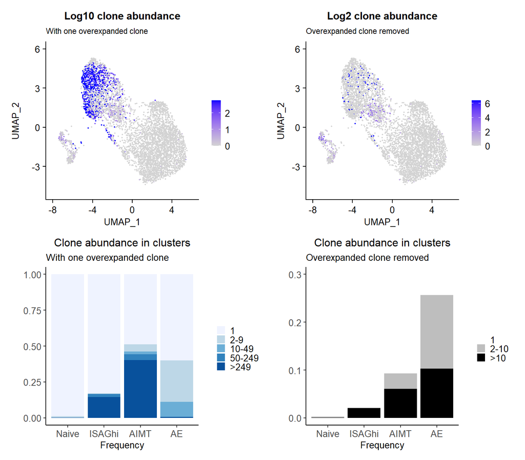

```r
# Create a data frame with Seurat metadata
metadata_df <- b6_blood.integrated@meta.data
rownames(metadata_df) <- colnames(b6_blood.integrated)

# Add the column for clone info
metadata_df <- metadata_df %>% mutate(
  clone_nt = paste(cdr3_B_nt,cdr3_A1_nt,cdr3_A2_nt),
  clone_aa = paste("CDR3b",cdr3_B,"CDR3a",cdr3_A1))

# Prepare a column for counting the clone abundance
metadata_df$test <- 0
metadata_df <- metadata_df %>% group_by(test, clone_aa) %>% mutate(clone_abundance = as.numeric(n()))

# Change NA values to "1" for the purpose of log scaling and plotting
metadata_df <- as.data.frame(metadata_df %>%
                  mutate(
                    clone_abundance_wo_expanded = as.numeric(
                      ifelse(clone_abundance %in% c(573, 291, 267), 1,clone_abundance)),
                    clone_abundance = as.numeric(
                      ifelse(clone_abundance %in% c(291), 1,clone_abundance))) %>%
                  mutate(log10_clone_abundance = log(clone_abundance, base = 10),
                      log2_clone_abundance_wo_expanded = log(clone_abundance_wo_expanded, base = 2)))

# Add the clone count info to the Seurat object
rownames(metadata_df) <- colnames(b6_blood.integrated)
b6_blood.integrated@meta.data <- metadata_df
rownames(b6_blood.integrated@meta.data) <- colnames(b6_blood.integrated)


# Log10 clone abundance
p13 <- FeaturePlot(b6_blood.integrated, reduction = "umap", features = "log10_clone_abundance")  + ggtitle("Log10 clone abundance", subtitle = "With one overexpanded clone") + ggtheme()

# Clone abundance without expanded
p14 <- FeaturePlot(b6_blood.integrated, reduction = "umap", features = "log2_clone_abundance_wo_expanded") + ggtheme() +
  ggtitle("Log2 clone abundance", subtitle = "Overexpanded clone removed") + ggtheme()

## With expanded clone
metadata_df <- metadata_df %>%
  mutate( clone_abundance_group = case_when(clone_abundance>249 ~ ">249",
                                            clone_abundance>49&clone_abundance<=249 ~ "50-249",
                                            clone_abundance>9&clone_abundance<=49 ~ "10-49",
                                            clone_abundance>1&clone_abundance<=9 ~ "2-9",
                                            clone_abundance==1 ~ "1",
                                            TRUE ~ "1"
                                            ))
## Bar plot
p15 <- metadata_df %>%
  ggplot(aes(x = factor(annot, levels = c("Naive","ISAGhi","AIMT","AE")))) +
  geom_bar(aes(fill = factor(clone_abundance_group, levels = c("1","2-9","10-49","50-249",">249"))), position = "fill") +   scale_fill_brewer(palette = "Blues") + xlab("Frequency")+ylab("") + theme_classic() + theme(plot.title = element_text(hjust = 0.5), legend.position="right", panel.border = element_blank(), legend.title = element_blank()) + ggtitle("Clone abundance in clusters", subtitle = "With one overexpanded clone") + ggtheme()



## Without expanded clone
metadata_df <- metadata_df %>%
  mutate( clone_abundance_group_wo_expanded = case_when(clone_abundance_wo_expanded>10 ~ ">10",
                                            clone_abundance_wo_expanded>2&clone_abundance_wo_expanded<=10 ~ "2-10",
                                            clone_abundance_wo_expanded==1 ~ "1",
                                            TRUE ~ "1"))

### Axis up to 30%
p16 <-  metadata_df %>%
  ggplot(aes(x = factor(annot, levels = c("Naive","ISAGhi","AIMT","AE")))) +
  geom_bar(aes(fill = factor(clone_abundance_group_wo_expanded, levels = c("1","2-10",">10"))), position = "fill") +
  scale_fill_manual(values = c("white","grey","black")) +
  xlab("Frequency") +
  ylab("") +
  theme_classic() +
  theme(plot.title = element_text(hjust = 0.5), legend.position="right", panel.border = element_blank(), legend.title = element_blank()) +
  ggtitle("Clone abundance in clusters", subtitle = "Overexpanded clone removed") +
   ylim(c(0,0.3)) +
  ggtheme()

p13 + p15 | p14 + p16
```

# Supplementary figure 1

## Fig S1A

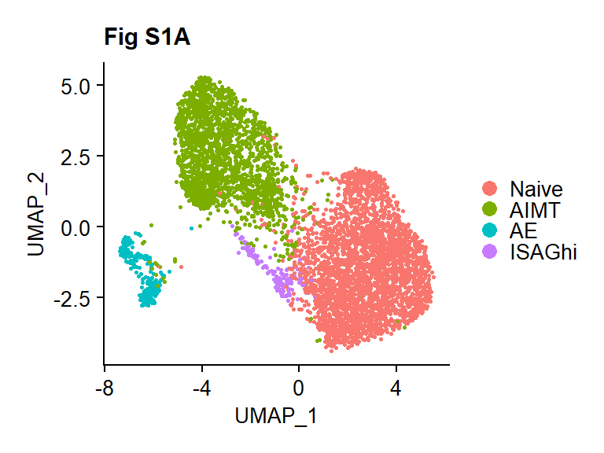

```r
## Supplement / all clusters
DimPlot(b6_blood.integrated, pt.size = 0.5)  + ggtitle("Fig S1A") + ggtheme()
```

## Fig S1B

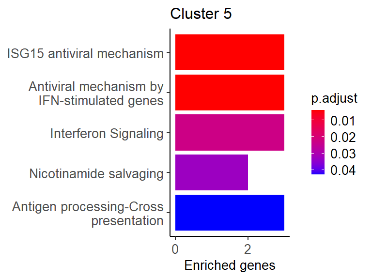

```r
# Filter markers of cluster 5 = ISAGhi
markers_cluster5_pos <- markers_filt %>% filter(cluster == 5 & avg_log2FC > 0)

# Convert gene names to EntrezIDs
gene_convert <- select(org.Mm.eg.db,
       keys = c(markers_cluster5_pos$gene),
       columns = c("ENTREZID", "SYMBOL"),
       keytype = "SYMBOL")

# Find enriched pathways
x <- enrichPathway(gene=gene_convert$ENTREZID, organism = "mouse", pvalueCutoff=0.05, readable=T)
df <- as.data.frame(x)
x2 <- enrichplot::pairwise_termsim(x)
pp2 <- barplot(x2) + ggtitle("Cluster 5")

# Plot the result
pp2 + theme_classic() + ggtheme() + scale_x_continuous(breaks = c(0,2,4,6,8,10)) + xlab("Enriched genes")
```

## Fig S1C

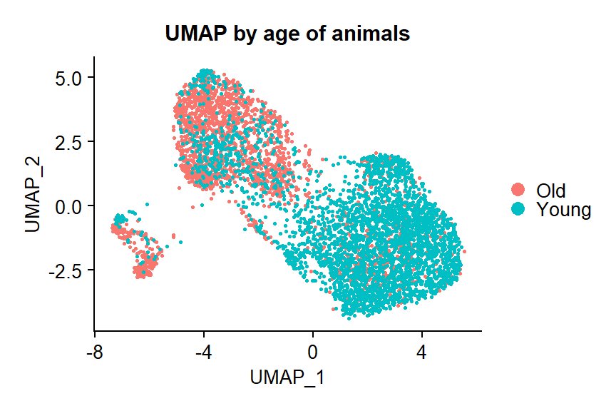

```r
b6_blood.integrated$age <- if_else(b6_blood.integrated$orig.ident == "E02_BOB6","Old","Young")
DimPlot(b6_blood.integrated, pt.size = 0.5, group.by = "age") + ggtheme() + ggtitle("UMAP by age of animals")
```

## Fig S1D

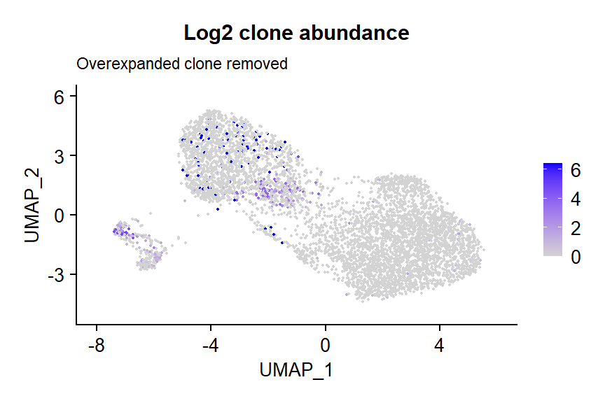

```r
p14 + ggtheme()
```